# Capstone

## Analyze

```r
table(tripdata_v2$member_casual)
```

```
##
##  casual  member
## 2316808 3344951
```

There are more members rides then casual.

Descriptive analysis on ride_length (all figures in mins)

```r
mean(tripdata_v2$ride_length) #straight average (total ride length / rides)
```

```
## Time difference of 16.33073 mins
```

```r
median(tripdata_v2$ride_length) #midpoint number in the ascending array of ride lengths
```

```
## Time difference of 10.26667 mins
```

```r
max(tripdata_v2$ride_length) #longest ride
```

```
## Time difference of 34294.07 mins
```

```r
min(tripdata_v2$ride_length) #shortest ride
```

```
## Time difference of 0 mins
```

Compare members and casual users by ride time.

```r
aggregate(tripdata_v2$ride_length ~ tripdata_v2$member_casual, FUN = mean)
```

```
##   tripdata_v2$member_casual tripdata_v2$ride_length
## 1                    casual           21.98804 mins
## 2                    member           12.41231 mins
```

```r
aggregate(tripdata_v2$ride_length ~ tripdata_v2$member_casual, FUN = median)
```

```
##   tripdata_v2$member_casual tripdata_v2$ride_length
## 1                    casual          12.966667 mins
## 2                    member           8.833333 mins
```

```r
aggregate(tripdata_v2$ride_length ~ tripdata_v2$member_casual, FUN = max)
```

```
##   tripdata_v2$member_casual tripdata_v2$ride_length
## 1                    casual          34294.067 mins
## 2                    member           1499.933 mins
```

```r
aggregate(tripdata_v2$ride_length ~ tripdata_v2$member_casual, FUN = min)
```

```
##   tripdata_v2$member_casual tripdata_v2$ride_length
## 1                    casual                  0 mins
## 2                    member                  0 mins
```

On average, member customers have shorter trips than the casual customers.

The average ride time by each day for members vs casual users.

```r
aggregate(tripdata_v2$ride_length ~ tripdata_v2$member_casual + tripdata_v2$weekday, FUN = mean)
```

```
##    tripdata_v2$member_casual tripdata_v2$weekday tripdata_v2$ride_length
## 1                     casual                   1           22.90325 mins
## 2                     member                   1           11.94899 mins
## 3                     casual                   2           19.99747 mins
## 4                     member                   2           11.77548 mins
## 5                     casual                   3           19.21040 mins
## 6                     member                   3           11.88415 mins
## 7                     casual                   4           19.38854 mins
## 8                     member                   4           11.98886 mins
## 9                     casual                   5           20.55960 mins
## 10                    member                   5           12.21362 mins
## 11                    casual                   6           24.08696 mins
## 12                    member                   6           13.74458 mins
## 13                    casual                   7           25.35769 mins
## 14                    member                   7           13.83766 mins
```

Analyze rider data by type and weekday.

```r
tripdata_v2 %>%
  mutate(weekday = wday(started_at, label = TRUE)) %>%  #creates weekday field using wday()
  group_by(member_casual, weekday) %>%  #groups by usertype and weekday
  summarise(number_of_rides = n()                           #calculates the number of rides and average duration
  ,average_duration = mean(ride_length_min)) %>%        # calculates the average duration
  arrange(member_casual, weekday)                               # sorts
```

```
## # A tibble: 14 × 4
## # Groups:   member_casual [2]
##    member_casual weekday number_of_rides average_duration
##    <chr>         <ord>             <int> <drtn>
##  1 casual        Вс               388011 25.09980 mins
##  2 casual        Пн               277054 22.62878 mins
##  3 casual        Вт               263187 19.63175 mins
##  4 casual        Ср               273823 19.00085 mins
##  5 casual        Чт               308713 19.67468 mins
##  6 casual        Пт               333938 20.53018 mins
##  7 casual        Сб               472082 24.64477 mins
##  8 member        Вс               387117 13.69630 mins
##  9 member        Пн               473249 12.00492 mins
## 10 member        Вт               518507 11.81100 mins
## 11 member        Ср               523770 11.83453 mins
## 12 member        Чт               532154 12.01070 mins
## 13 member        Пт               466985 12.22584 mins
## 14 member        Сб               443169 13.79091 mins
```

## Share

### Rides by day of the week

Lets visualize the number of rides by rider type.

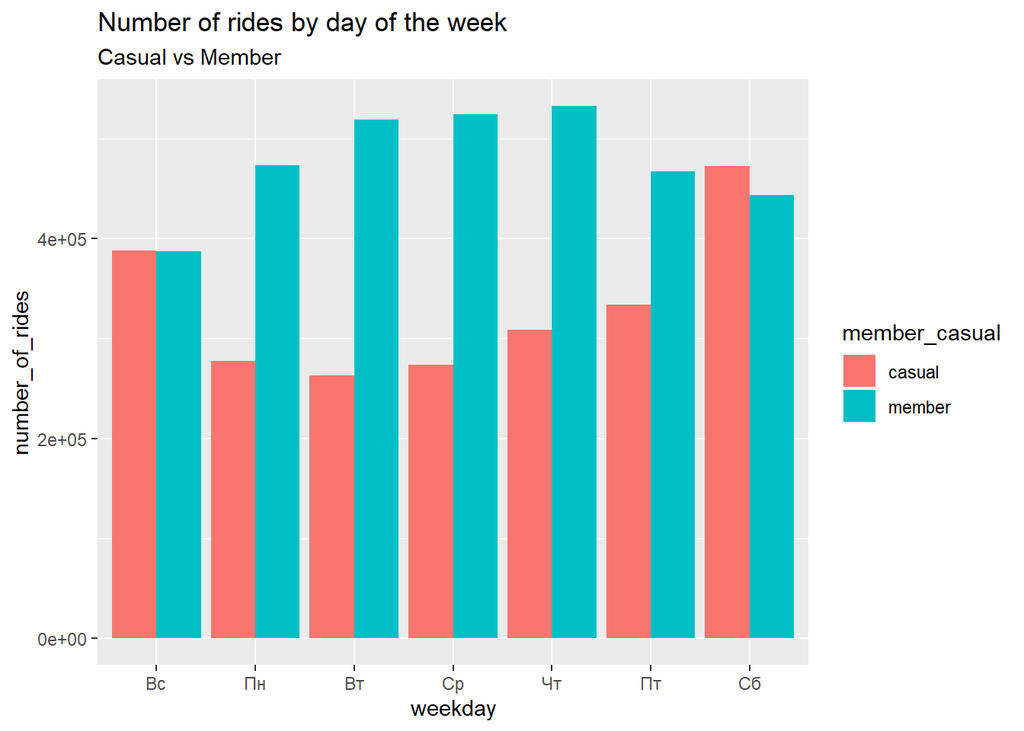

```r
tripdata_v2 %>%
  mutate(weekday = wday(started_at, label = TRUE)) %>%
  group_by(member_casual, weekday) %>%
  summarise(number_of_rides = n(), average_duration = mean(ride_length_min)) %>%
  arrange(member_casual, weekday)  %>%
  ggplot(aes(x = weekday, y = number_of_rides, fill = member_casual)) +
  geom_col(position = "dodge") +
  labs(title = "Number of rides by day of the week"
       , subtitle = "Casual vs Member")
```

Lets create a visualization for average duration.

```
## Defaulting to continuous.
```

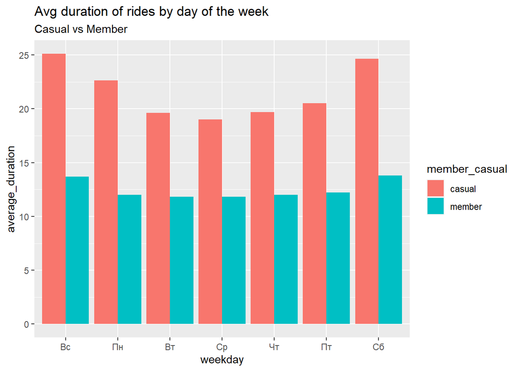

```r
tripdata_v2 %>%
  mutate(weekday = wday(started_at, label = TRUE)) %>%
  group_by(member_casual, weekday) %>%
  summarise(number_of_rides = n(), average_duration = mean(ride_length_min)) %>%
  arrange(member_casual, weekday)  %>%
  ggplot(aes(x = weekday, y = average_duration, fill = member_casual)) +
  geom_col(position = "dodge") +
  labs(title = "Avg duration of rides by day of the week"
       , subtitle = "Casual vs Member")
```

### Rides by month

Lets visualize the number of rides by rider type.

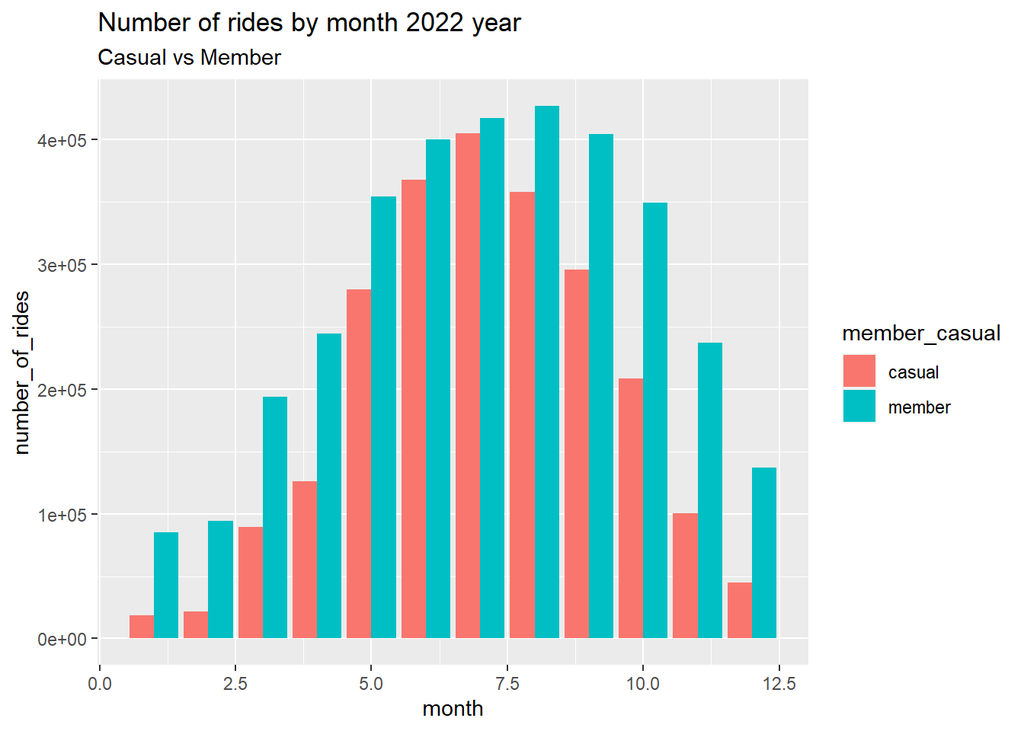

```r
tripdata_v2 %>%
  group_by(member_casual, month) %>%
  summarise(number_of_rides = n(), average_duration = mean(ride_length_min)) %>%
  arrange(member_casual, month)  %>%
  ggplot(aes(x = month, y = number_of_rides, fill = member_casual)) +
  geom_col(position = "dodge") +
  labs(title = "Number of rides by month 2022 year"
       , subtitle = "Casual vs Member")
```

Lets create a visualization for average duration.

```
## Defaulting to continuous.
```

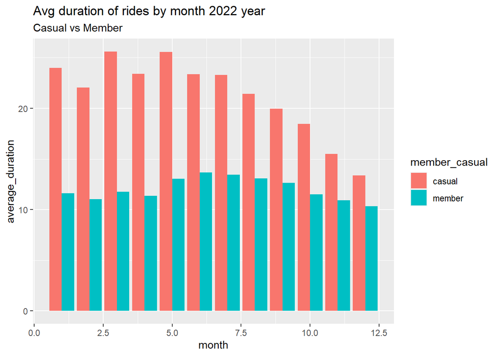

```r
tripdata_v2 %>%
  group_by(member_casual, month) %>%
  summarise(number_of_rides = n(), average_duration = mean(ride_length_min)) %>%
  arrange(member_casual, month)  %>%
  ggplot(aes(x = month, y = average_duration, fill = member_casual)) +
  geom_col(position = "dodge") +
  labs(title = "Avg duration of rides by month 2022 year"
       , subtitle = "Casual vs Member")
```

## Act

- The casual riders take their bikes for longer rides than the members do.
- The casual riders are more likely to use their bikes to ride on weekends.
- The member riders are likely to use their bikes on work days.

For a more in-depth analysis we need more client data such as: client ID in the system, classification of stations depending on the city district (center, cultural area, downtown, countryside), the number and volume of payments, popular destinations for a particular client etc.

Offer clients who get to work an member annual plan, if he or she does not already have one. See who the casual client uses the bike most of the week and let them know about the features and convenience of the annual plan. For more detailed recommendations, I will need a little more information than what was presented.